# Lab5 Team

Jian Kai Lee;jiankailee / Nick Matthews;nickmatthews713

4/12/2020

### Loading in files

```r
library(ggplot2)
library(dplyr)
library(maps)
library(mapproj)
library(tidyr)
acc <- read.csv("https://raw.githubusercontent.com/xdaiISU/ds202materials/master/hwlabs/fars2017/accident.csv", stringsAsFactors = FALSE)
person <- read.csv("https://raw.githubusercontent.com/xdaiISU/ds202materials/master/hwlabs/fars2017/person.csv", stringsAsFactors = FALSE)
```

### Part 1: Accident Data

#### Problem 1

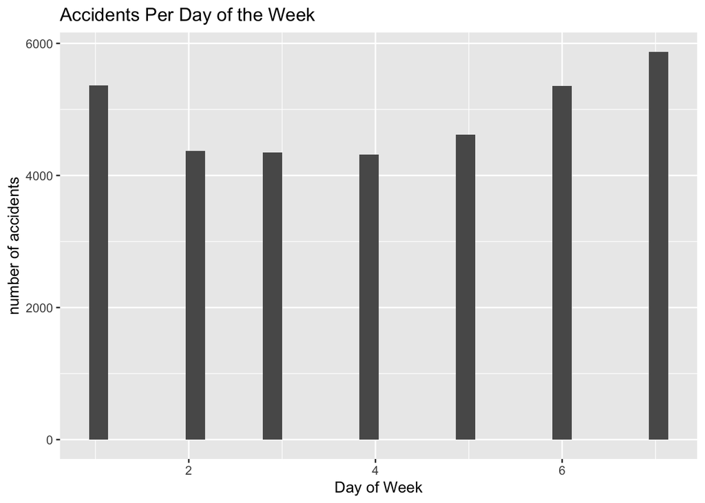

```r
acc %>%ggplot(aes(x=DAY_WEEK))+geom_histogram()+xlab("Day of Week")+ylab("number of accidents") +
  ggtitle("Accidents Per Day of the Week")
```

#### Problem 2

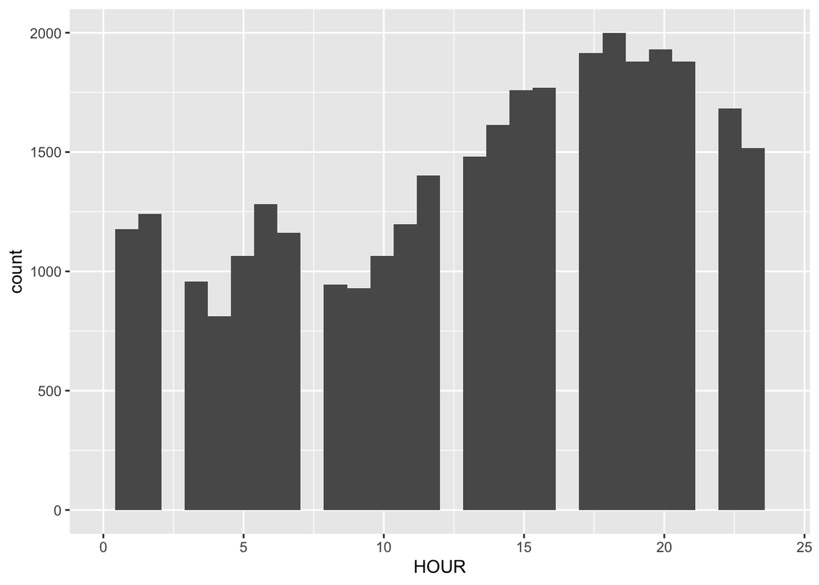

```r
acc%>%ggplot(aes(x=HOUR))+geom_histogram()+xlim(0,24)
```

##### Description:

From the histogram, we can see the most accidents happened between 17 and 21 which are 5 pm to 9pm. People tend to drive home from work or go out for dinner.

#### Problem 3

```r
temp<-acc%>%filter(DRUNK_DR>=1)
length(temp)
```

```
## [1] 52
```

### part 2: Connecting Data

#### Problem 4

```r
person_sub<-person%>%filter(PER_TYP==1)
```

##### Description:

when “PER_TYP” = 1, it refers to the person driving the motor vehicle

#### Problem 5

```r
joined <- inner_join(person_sub, acc, by=c("ST_CASE","DAY","MONTH","HOUR","MINUTE","STATE","VE_FORMS","COUNTY"))
```

##### Description:

I assume we are trying to join together the data and try to match each person to the accident, so I made sure to join along many details down to the minute of when the crash happened.

#### Problem 6

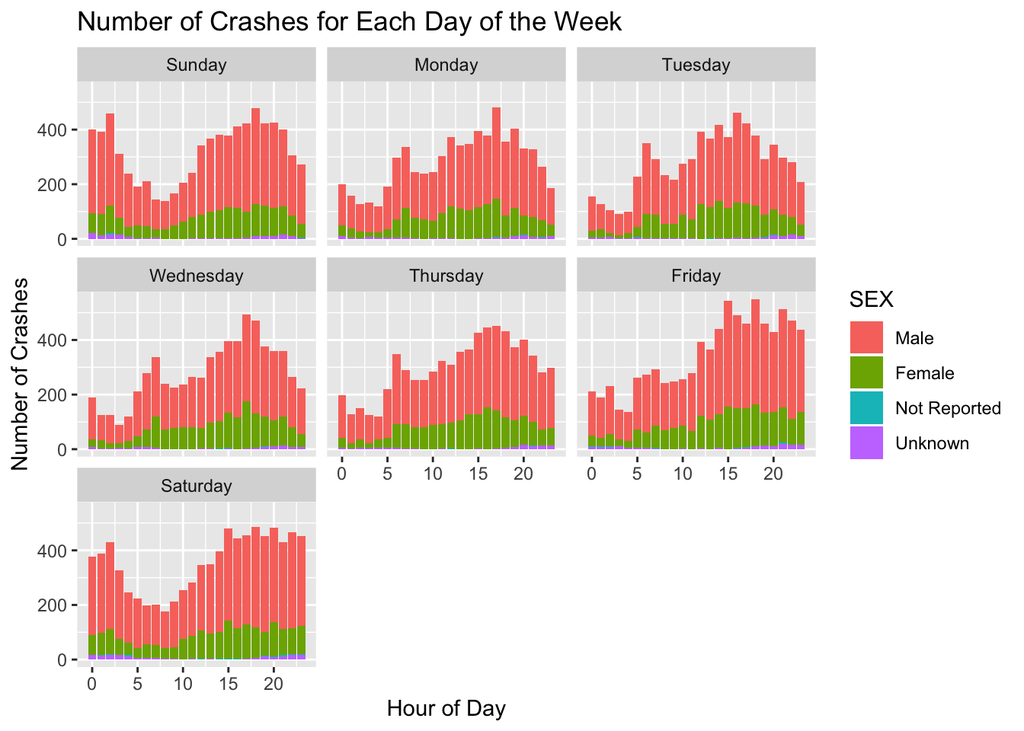

```r
joined$SEX <- as.factor(joined$SEX)
levels(joined$SEX) <- c("Male","Female","Not Reported","Unknown")

joined$DAY_WEEK <- as.factor(joined$DAY_WEEK)
levels(joined$DAY_WEEK) <- c("Sunday","Monday","Tuesday","Wednesday","Thursday","Friday","Saturday")

joined %>%
  group_by(DAY_WEEK, HOUR, SEX) %>%
  summarise(count = n()) %>%
  filter(HOUR < 25) %>%
  ggplot(aes(x=HOUR, y=count, fill=SEX)) + geom_bar(stat="identity") + facet_wrap(~DAY_WEEK) +
  ylab("Number of Crashes") + xlab("Hour of Day") + ggtitle("Number of Crashes for Each Day of the Week")
```

##### Description:

Here is the amount of accidents for every hour for each day of the week, also displaying the gender by color. I factored the columns SEX and DAY_WEEK to make the graph more readable. I had to do a filter(HOUR < 25) because there is a row in the dataset where the HOUR is 100. This didn’t make any sense, so I removed it.

### Part 3: Connecting Data and Make Maps

#### Problem 7/8

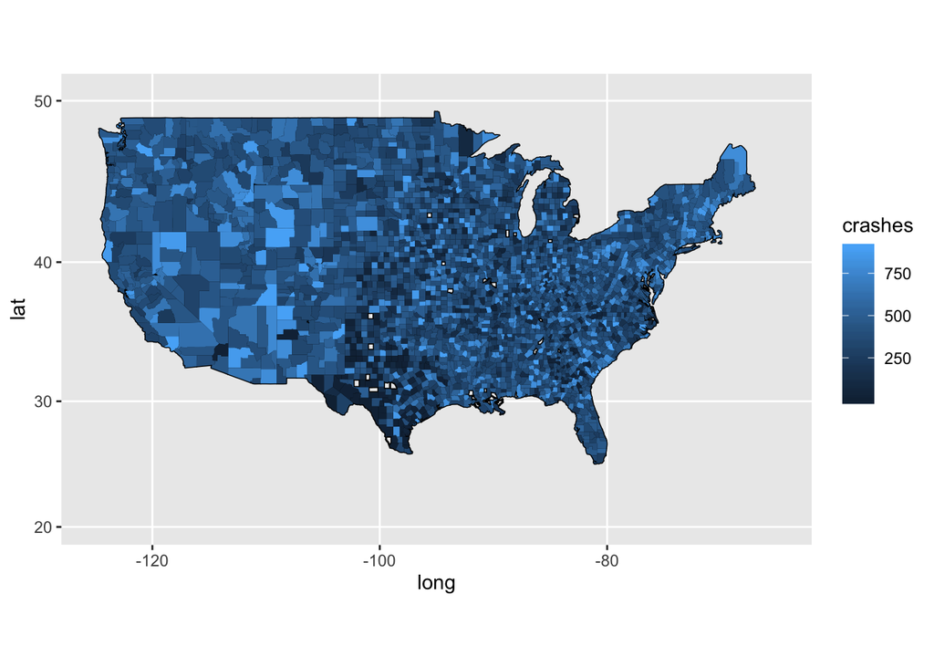

```r
countys = map_data('county')
states = map_data('state')
GLC = readxl::read_xlsx('counties.xlsx')
GLC$`County Name` = tolower(GLC$`County Name`)
GLC$`State Name` = tolower(GLC$`State Name`)

countyCodes <- unique(GLC %>% select(`County Name`,`County Code`))

# summarise the accident date to get number of crashes per county
countyCases <- acc %>%
  group_by(COUNTY) %>% summarise(crashes = n())

# join together data to geocode and then use the polynames to get longitude and latitude from counties
countyData <- countyCases %>%
  inner_join(countyCodes %>% mutate('County Code' = as.numeric(countyCodes$'County Code')),
             by=c(COUNTY='County Code'))  %>%
  inner_join(countys, by=c(`County Name` = 'subregion'))

# plot the states map along with all the counties on it, coloring the counties according to the number of crashes
countys %>%
  ggplot(aes(x=long, y=lat)) + geom_path(aes(group = group)) + coord_map() +
  geom_polygon(data = countyData, aes(x=long, y=lat, group=group, fill=crashes),
             size=0.05) +
  xlim(c(-125,-65)) + ylim(c(20,50))
```

#### Problem 9

[figure not shown]

```r
summerAcc <- acc %>% filter(MONTH < 4 | MONTH > 11) # Winter
winterAcc <- acc %>% filter(MONTH < 9 | MONTH > 4) #Summer

GLC$'State Code' = as.numeric(GLC$'State Code')
stateCodes <- unique(GLC %>% select(`State Name`,`State Code`))

winterAcc %>%
  group_by(STATE) %>%
  summarise(crashes = n()) %>%
  inner_join(stateCodes, by=c(STATE="State Code")) %>%
  inner_join(states, by=c(`State Name`="region")) %>%
  ggplot(aes(x=long,y=lat)) +
  geom_polygon(aes(group=group, fill = crashes)) +
  ggtitle("Crashes by State During the Winter") +
  scale_fill_gradientn(limits=c(0,3500),
                       colours=c("navyblue", "darkmagenta", "darkorange1"))
```

[figure not shown]

```r
summerAcc %>%
  group_by(STATE) %>%
  summarise(crashes = n()) %>%
  inner_join(stateCodes, by=c(STATE="State Code")) %>%
  inner_join(states, by=c(`State Name`="region")) %>%
  ggplot(aes(x=long,y=lat)) +
  geom_polygon(aes(group=group, fill = crashes)) +
  ggtitle("Crashes by State During the Summer") +
  scale_fill_gradientn(limits=c(0,3500),
                       colours=c("navyblue", "darkmagenta", "darkorange1"))
```